# Observing with `astroplan`

## I have given you:

- Three locations
- An observing date
- Some target objects

```python
import matplotlib.pyplot as plt

import numpy as np
import astropy.units as u
from astropy.time import Time
import pytz

from astroplan.plots import plot_airmass
from astroplan import Observer, FixedTarget, time_grid_from_range

import warnings
warnings.simplefilter('ignore', Warning)
```

# Set up the locations

- [Google](https://www.google.com/), [Google Maps](https://www.google.com/maps), and [Google Earth](https://www.google.com/earth/) are good resources to find Latitude and Longitude.
- [Timezone Map](https://uwashington-astro300.github.io/A300_images/TZ.png) is good for timezones
- Make sure you have not switched the Lat and Lon!

Location #1 - Cerro Mellizo Sur Aysén, Chile Location #2 - Mount Tambora West Nusa Tenggara, Indonesia Location #3 - Canadian Forces Station Alert Nunavut, Canada

```python
# Location 1

my_location_one = Observer(longitude = -73.14074750668829 * u.deg,
                         latitude = -48.55474333867469 * u.deg,
                         timezone = 'America/Santiago',
                         name = "Cerro Mellizo Sur Aysén, Chile"
                        )
```

```python
# Location 2

my_location_two = Observer(longitude = 117.99135843232759 * u.deg,
                         latitude = -8.24720230309624 * u.deg,
                         timezone = 'Asia/Makassar',
                         name = "Mount Tambora West Nusa Tenggara, Indonesia"
                        )
```

```python
# Location 3

my_location_three = Observer(longitude = -62.34584445101083 * u.deg,
                         latitude = 82.49886570465698 * u.deg,
                         timezone = 'America/Toronto',
                         name = "Canadian Forces Station Alert Nunavut, Canada"
                        )
```

# Determine the UTC time for **Local Noon** at each of the locations

# Observing Date: **Dec 24, 2026**

- You will have to experiment with the `which =` parameter
- Make sure local noon occurs on the observing date

```python
# Location 1

my_date = Time("2026-12-24")
my_noon_one = my_location_one.noon(my_date, which="next")

print(my_noon_one.iso)
```

```
2026-12-24 16:52:12.308
```

```python
# Location 2

my_noon_two = my_location_two.noon(my_date, which="next")

print(my_noon_two.iso)
```

```
2026-12-24 04:07:25.988
```

```python
# Location 3

my_noon_three = my_location_three.noon(my_date, which="next")

print(my_noon_three.iso)
```

```
2026-12-24 16:09:07.719
```

# Determine the length of the observing run at each location

- Length of run is defined by **Astronomical Twilight**
- If your length is negative (or > 24 hr), you have to use a different `which =` parameter above
- Your output should look like - `At LOCATION the total observing time is TIME hours`
- The observing length should be VERY different at each location

```python
# Location 1

observe_night_one = my_location_one.tonight(my_noon_one, horizon = -18 * u.deg)
```

```python
# Print out observing length

observing_length_one = (observe_night_one[1] - observe_night_one[0]).to(u.h)

print(f"At {my_location_one.name} the total observing time is {observing_length_one.value:.1f} hours")
```

```
At Cerro Mellizo Sur Aysén, Chile the total observing time is 0.4 hours
```

```python
# Location 2

observe_night_two = my_location_two.tonight(my_noon_two, horizon = -18 * u.deg)
```

```python
# Print out observing length

observing_length_two = (observe_night_two[1] - observe_night_two[0]).to(u.h)

print(f"At {my_location_two.name} the total observing time is {observing_length_two.value:.1f} hours")
```

```
At Mount Tambora West Nusa Tenggara, Indonesia the total observing time is 8.8 hours
```

```python
# Location 3

observe_night_three = my_location_three.tonight(my_noon_three, horizon = -18 * u.deg)
```

```python
# Print out observing length

observing_length_three = (observe_night_three[1] - observe_night_three[0]).to(u.h)

print(f"At {my_location_three.name} the total observing time is {observing_length_three.value:.1f} hours")
```

```
At Canadian Forces Station Alert Nunavut, Canada the total observing time is 18.0 hours
```

# Set up the Target list

- NGC 6720
- NGC 2548
- NGC 2068
- NGC 5024
- NGC 2535
- Your object from the last Homework that you retrived an image from POSS

```python
target1 = FixedTarget.from_name("NGC 6720")
target2 = FixedTarget.from_name("NGC 2548")
target3 = FixedTarget.from_name("NGC 2068")
target4 = FixedTarget.from_name("NGC 5024")
target5 = FixedTarget.from_name("NGC 2535")
target6 = FixedTarget.from_name("NGC 2685")
```

```python
target_list = [target1, target2, target3, target4, target5, target6]
target_list
```

```
[<FixedTarget "NGC 6720" at SkyCoord (ICRS): (ra, dec) in deg (283.39623652, 33.02913425)>,
 <FixedTarget "NGC 2548" at SkyCoord (ICRS): (ra, dec) in deg (123.39167, -5.71972)>,
 <FixedTarget "NGC 2068" at SkyCoord (ICRS): (ra, dec) in deg (86.69083, 0.07917)>,
 <FixedTarget "NGC 5024" at SkyCoord (ICRS): (ra, dec) in deg (198.230208, 18.168167)>,
 <FixedTarget "NGC 2535" at SkyCoord (ICRS): (ra, dec) in deg (122.8061833, 25.2069361)>,
 <FixedTarget "NGC 2685" at SkyCoord (ICRS): (ra, dec) in deg (133.89459492, 58.73441015)>]
```

# What can you see at each location?

## For each location, plot airmass vs. time for all of the targets over the observing night

- Each location will have different observing night parameters

```python
my_time_grid_one = time_grid_from_range(observe_night_one, time_resolution = 0.1 * u.h)
```

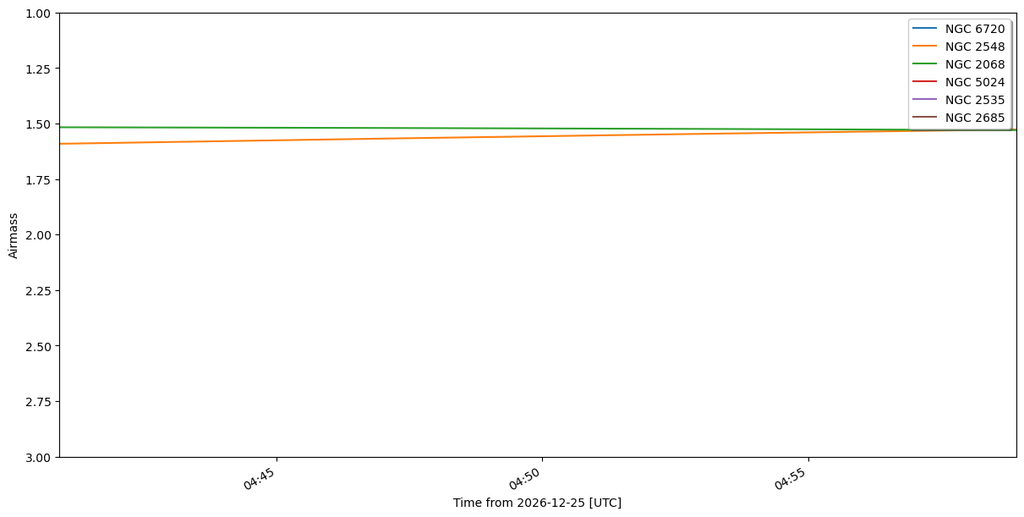

```python
fig, ax = plt.subplots(
    figsize = (12, 6),
    constrained_layout = True
)

for my_object in target_list:
    ax = plot_airmass(my_object, my_location_one, my_time_grid_one)

ax.legend(loc=0,shadow=True);
```

```python
my_time_grid_two = time_grid_from_range(observe_night_two, time_resolution = 0.1 * u.h)
```

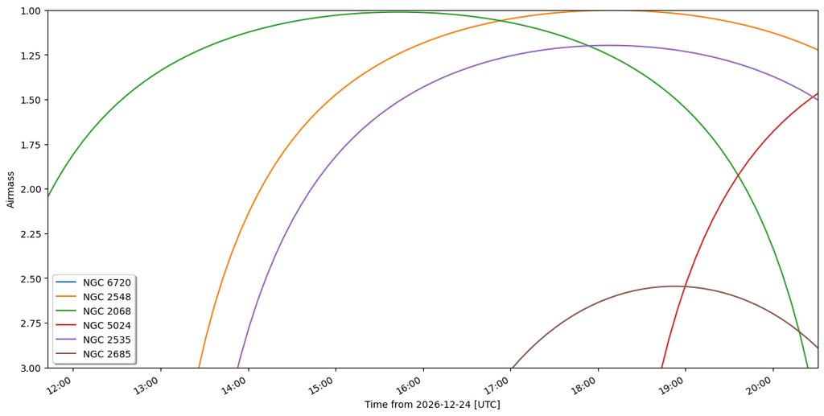

```python
fig, ax = plt.subplots(
    figsize = (12, 6),
    constrained_layout = True
)

for my_object in target_list:
    ax = plot_airmass(my_object, my_location_two, my_time_grid_two)

ax.legend(loc=0,shadow=True);
```

```python
my_time_grid_three = time_grid_from_range(observe_night_three, time_resolution = 0.1 * u.h)
```

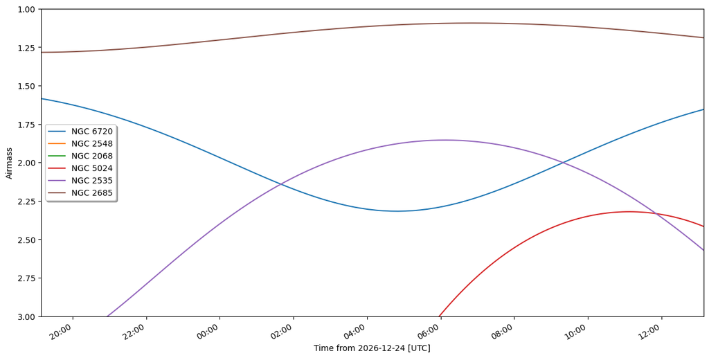

```python
fig, ax = plt.subplots(
    figsize = (12, 6),
    constrained_layout = True
)

for my_object in target_list:
    ax = plot_airmass(my_object, my_location_three, my_time_grid_three)

ax.legend(loc=0,shadow=True);
```

### Due Mon Feb 23 - 1 pm

- `File -> Download as -> HTML (.html)`
- `upload your .html file to the class Canvas page`

# `astroplan` - Constraints

## ⭐ Add ALL of the following cells to the END of your Observing assignment. ⭐

- Re-run all of the cells of your Observing assignment first.
- And then run the cells below.

```python
from astropy.table import QTable

from astropy.coordinates import SkyCoord
from astroplan import observability_table
from astroplan import AltitudeConstraint, MoonSeparationConstraint, SunSeparationConstraint
```

# Targets

- Setup the targets from the data file `https://uwashington-astro300.github.io/A300_Data/BrightStars_50.csv` and create a target list.
- The columns are:
  - Name
  - RA (hours)
  - DEC (deg)
- Add units to the columns

```python
target_table = QTable.read('https://uwashington-astro300.github.io/A300_Data/BrightStars_50.csv',
                           format='ascii.csv')
```

```python
target_table['RA'].unit = u.hourangle
target_table['DEC'].unit = u.deg

target_table[0:3]
```

*QTable length=3*

| Name str15 | RA hourangle float64 | DEC deg float64 |
| --- | --- | --- |
| Sirius | 6.7525694 | -16.71314306 |
| Canopus | 6.39919184 | -52.69571799 |
| Arcturus | 14.2612076 | 19.18726997 |

```python
my_targets = [FixedTarget(coord = SkyCoord(ra = my_RA, dec = my_DEC), name = my_Name) #FixedTraget: 관측시에 좌표를 input하는 함수
           for my_Name, my_RA, my_DEC in target_table]
```

## For each of the 3 locations create an `observability_table` with the following constraints

#### Use the new target list

- Same observing date (12/24/2026)
- The time range will be different for each location
- Constraints:
  - Target > 6 hours from Sun
  - Target > 60 degrees from Moon
  - Target Altitude > 60 degrees

#### Print out the table for each location showing **ONLY** the objects that are observable

```python
observing_date=Time("2026-12-24")
```

```python
my_time_range_one = [observe_night_one[0],observe_night_one[1]]
my_time_range_two = [observe_night_two[0],observe_night_two[1]]
my_time_range_three = [observe_night_three[0],observe_night_three[1]]
```

```python
my_constraints = [SunSeparationConstraint(6 * u.hourangle)]
my_constraints.append(MoonSeparationConstraint(60 * u.deg))
my_constraints.append(AltitudeConstraint(min=60*u.deg, max=None))
```

```python
observing_table_one = observability_table(my_constraints,
                                      my_location_one,
                                      my_targets,
                                      time_range = my_time_range_one
                                     )
observing_table_one[observing_table_one['ever observable'] == True]
```

*Table length=1*

| target name str15 | ever observable bool | always observable bool | fraction of time observable float64 |
| --- | --- | --- | --- |
| Canopus | True | True | 1.0 |

```python
observing_table_two = observability_table(my_constraints,
                                      my_location_two,
                                      my_targets,
                                      time_range = my_time_range_two
                                     )
observing_table_two[observing_table_two['ever observable'] == True]
```

*Table length=1*

| target name str15 | ever observable bool | always observable bool | fraction of time observable float64 |
| --- | --- | --- | --- |
| Diphda | True | False | 0.1111111111111111 |

```python
observing_table_three = observability_table(my_constraints,
                                      my_location_three,
                                      my_targets,
                                      time_range = my_time_range_three
                                     )
observing_table_three[observing_table_three['ever observable'] == True]
```

*Table length=4*

| target name str15 | ever observable bool | always observable bool | fraction of time observable float64 |
| --- | --- | --- | --- |
| Alioth | True | False | 0.32432432432432434 |
| Polaris | True | True | 1.0 |
| Kochab | True | True | 1.0 |
| Mizar | True | False | 0.2702702702702703 |

## For each Location create a summary paragraph:

#### If there is more than one target with the same "longest observing time" - just pick one.

- Use `f-string` formatting to make your output look nice
- All floats should be printed to one decimal place
- Replace the CAP values with data. **DO NOT HARDCODE!!** - use variables.

On DATE at LOCATION you can observe NUMBER targets over the observing night. The observing night at LOCATION is NUMBER hours long. The target with the longest time for observation is TARGET_NAME with a total of NUMBER hours of observing.

### Location 1

```python
observing_table_one.sort('fraction of time observable')
fraction_max_one = observing_table_one[-1]['fraction of time observable']


print(f'''On {observing_date} at {my_location_one.name} you can observe {len(observing_table_one[observing_table_one['ever observable'] == True])} targets over the observing night.
The observing night at {my_location_one.name} is {observing_length_one.value:.1f} hours long.
The target with the longest time for observation is {observing_table_one[-1]['target name']} with a total of {(fraction_max_one * observing_length_one.value):.1f} hours of observing.''')
```

```
On 2026-12-24 00:00:00.000 at Cerro Mellizo Sur Aysén, Chile you can observe 1 targets over the observing night.
The observing night at Cerro Mellizo Sur Aysén, Chile is 0.4 hours long.
The target with the longest time for observation is Canopus with a total of 0.4 hours of observing.
```

### Location 2

```python
observing_table_two.sort('fraction of time observable')
fraction_max_two = observing_table_two[-1]['fraction of time observable']


print(f'''On {observing_date} at {my_location_two.name} you can observe {len(observing_table_two[observing_table_two['ever observable'] == True])} targets over the observing night.
The observing night at {my_location_two.name} is {observing_length_two.value:.1f} hours long.
The target with the longest time for observation is {observing_table_two[-1]['target name']} with a total of {(fraction_max_two * observing_length_two.value):.1f} hours of observing.''')
```

```
On 2026-12-24 00:00:00.000 at Mount Tambora West Nusa Tenggara, Indonesia you can observe 1 targets over the observing night.
The observing night at Mount Tambora West Nusa Tenggara, Indonesia is 8.8 hours long.
The target with the longest time for observation is Diphda with a total of 1.0 hours of observing.
```

### Location 3

```python
observing_table_three.sort('fraction of time observable')
fraction_max_three = observing_table_three[-1]['fraction of time observable']


print(f'''On {observing_date} at {my_location_three.name} you can observe {len(observing_table_three[observing_table_three['ever observable'] == True])} targets over the observing night.
The observing night at {my_location_three.name} is {observing_length_three.value:.1f} hours long.
The target with the longest time for observation is {observing_table_three[-1]['target name']} with a total of {(fraction_max_three * observing_length_three.value):.1f} hours of observing.''')
```

```
On 2026-12-24 00:00:00.000 at Canadian Forces Station Alert Nunavut, Canada you can observe 4 targets over the observing night.
The observing night at Canadian Forces Station Alert Nunavut, Canada is 18.0 hours long.
The target with the longest time for observation is Polaris with a total of 18.0 hours of observing.
```

### Due Wed Feb 25 - 1 pm

- `File -> Download as -> HTML (.html)`
- `upload your .html file to the class Canvas page`